# Supermarket Data Analysis

Thomas Chula

2025-12-06

# 1 Executive Summary

This report analyzes 1000 transactions generating $322,967 in revenue over the observation period.

**Key Highlights:**

- Average transaction value: $322.97
- 50.1 % of customers are members.
- Overall customer satisfaction rating: 7/10.
- Data spans 3 cities and 6 product categories

# 2 Customer Demographics

## 2.1 Customer Type Distribution

Customer Type Analysis

| customer_type | Count | Percentage | Avg_Transaction | Total_Revenue | Avg_Rating |
| --- | --- | --- | --- | --- | --- |
| Member | 501 | 50 | 327.79 | 164223.4 | 6.9 |
| Normal | 499 | 50 | 318.12 | 158743.3 | 7.0 |

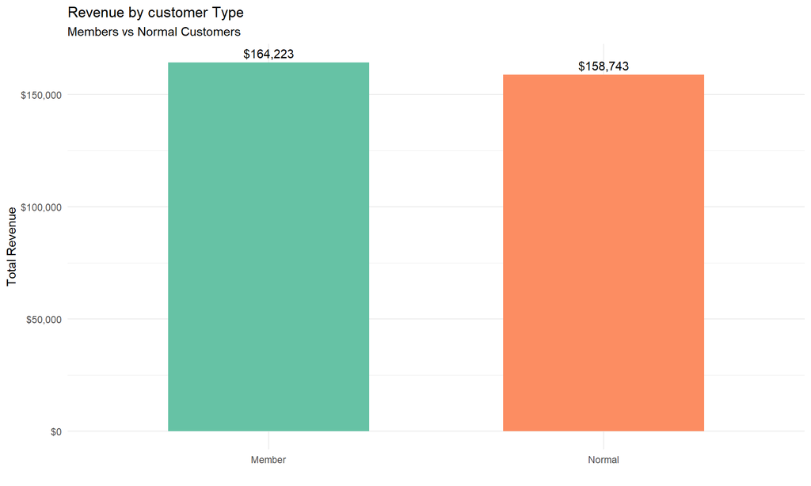

**Insight:** While Members represent 50% of customers, their average transaction value is $327.79 compared to $318.12 for normal customers.

## 2.2 Gender Distribution

Gender-Base Analysis

| Gender | Count | Percentage | Avg_Spend | Avg_Rating |
| --- | --- | --- | --- | --- |
| Female | 501 | 50.1 | 335.10 | 7 |
| Male | 499 | 49.9 | 310.79 | 7 |

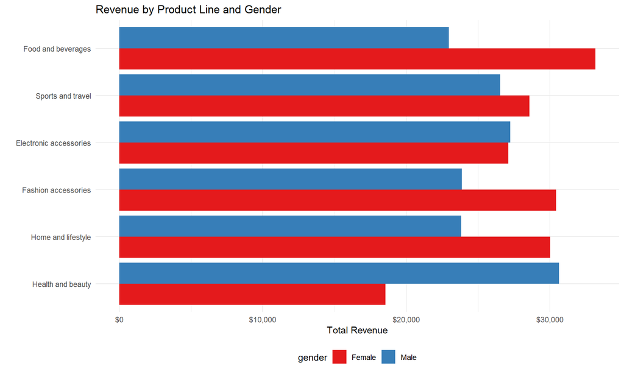

# 3 Product Performance

## 3.1 Top Performing Product Lines

Product Line Performance

| product_line | Transactions | Percentage | Avg_Unit_Price | Avg_Quantity | Total_Revenue | Avg_Rating |
| --- | --- | --- | --- | --- | --- | --- |
| Food and beverages | 174 | 17.4 | 56.01 | 5.5 | 56145 | 7.1 |
| Sports and travel | 166 | 16.6 | 56.99 | 5.5 | 55123 | 6.9 |
| Electronic accessories | 170 | 17.0 | 53.55 | 5.7 | 54338 | 6.9 |
| Fashion accessories | 178 | 17.8 | 57.15 | 5.1 | 54306 | 7.0 |
| Home and lifestyle | 160 | 16.0 | 55.32 | 5.7 | 53862 | 6.8 |
| Health and beauty | 152 | 15.2 | 54.85 | 5.6 | 49194 | 7.0 |

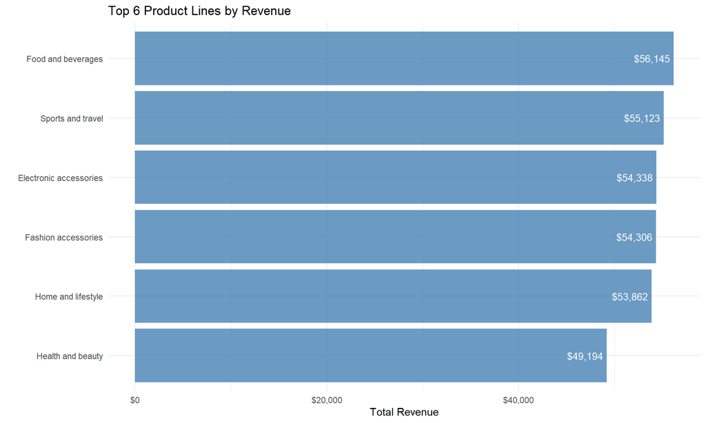

## 3.2 Product Rating Analysis

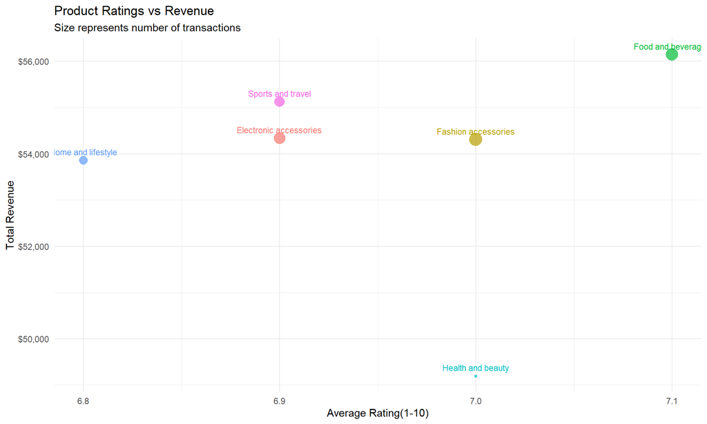

# 4 Temporal Patterns

## 4.1 Daily Shopping Patterns

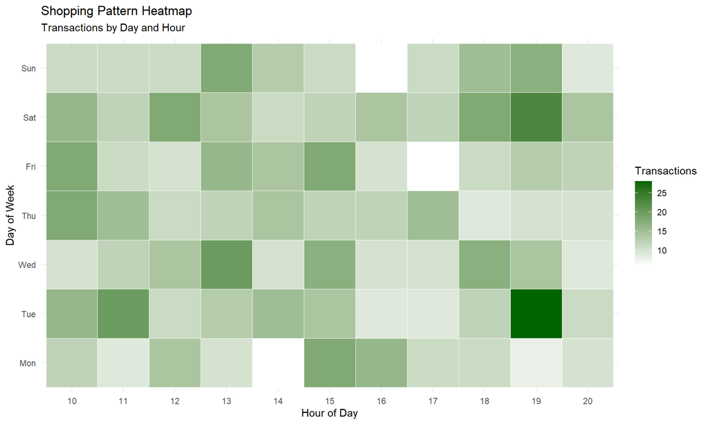

## 4.2 Peak Hours Analysis

Top 5 Peak Shopping Hours

| hour | Transactions | Total_Revenue | Avg_Transaction |
| --- | --- | --- | --- |
| 19 | 113 | 39699.51 | 351.3231 |
| 13 | 103 | 34723.23 | 337.1187 |
| 15 | 102 | 31179.51 | 305.6815 |
| 10 | 101 | 31421.48 | 311.1038 |
| 18 | 93 | 26030.34 | 279.8961 |

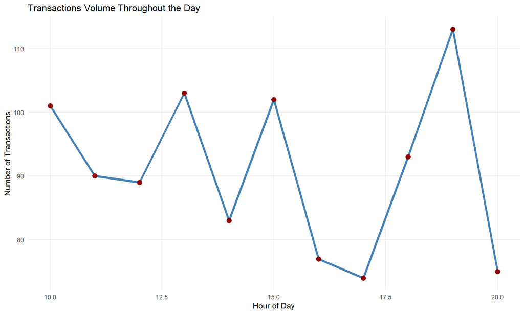

**Finding:** The busiest hour is 19:00 with 113 transactions. Consider staffing adjustments during peak periods.

# 5 Financial Analysis

## 5.1 Payment Method Preferences

Payment Method Analysis

| payment | Count | Percentage | Avg_Amount | Total_Amount |
| --- | --- | --- | --- | --- |
| Ewallet | 345 | 34.5 | 318.82 | 109993 |
| Cash | 344 | 34.4 | 326.18 | 112207 |
| Credit card | 311 | 31.1 | 324.01 | 100767 |

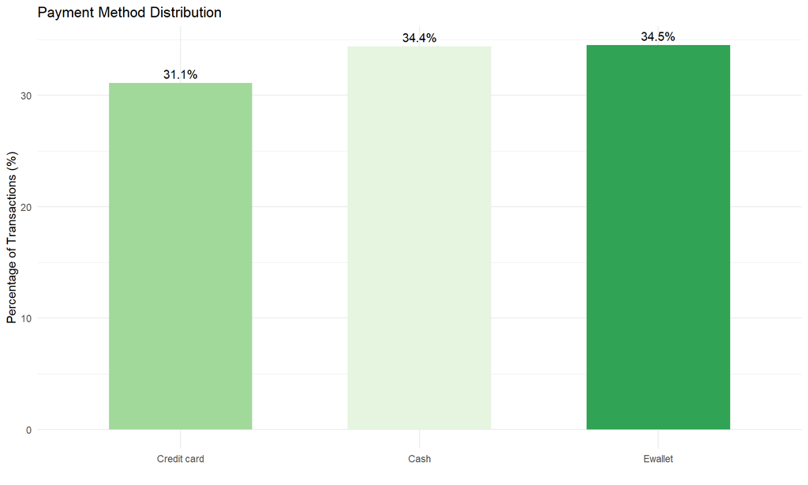

# 6 Branch Performance Comparison

Branch Performance Comparison

| branch | city | Transactions | Percentage | Total_Revenue | Avg_Transaction | Avg_Rating |
| --- | --- | --- | --- | --- | --- | --- |
| C | Naypyitaw | 328 | 32.8 | 110569 | 337.10 | 7.1 |
| A | Yangon | 340 | 34.0 | 106200 | 312.35 | 7.0 |
| B | Mandalay | 332 | 33.2 | 106198 | 319.87 | 6.8 |

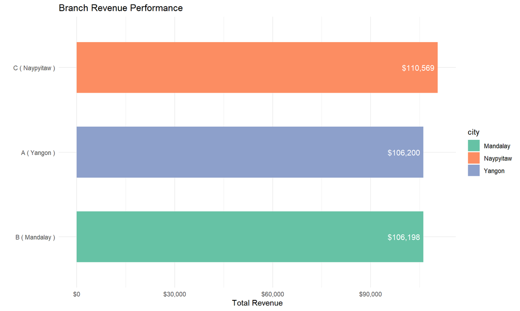

**Insights**: Branch C in Naypyitaw is the top performer with $110,569 in revenue.

# 7 Customer Value Segmentation

Customer Value Segmentation

| Segment | Customer | Percentage | Avg_Total_Spent | Avg_Visits | Revenue_Share |
| --- | --- | --- | --- | --- | --- |
| High Value | 200 | 20 | 546.45 | 1 | 33.8 |
| Low Value | 400 | 40 | 104.26 | 1 | 12.9 |
| Medium Value | 300 | 30 | 293.89 | 1 | 27.3 |
| VIP | 100 | 10 | 838.08 | 1 | 25.9 |

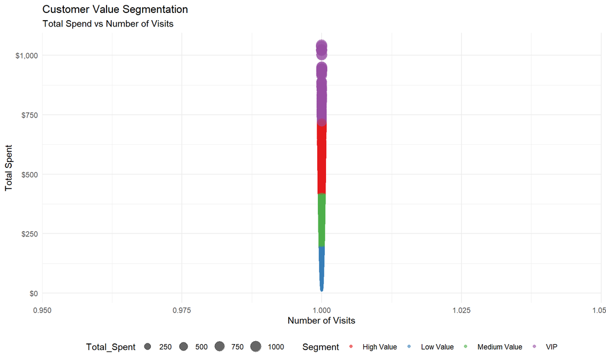

**Critical Finding:** The top 10% of customers (VIP segment) account for 25.9% of total revenue!

# 8 Correlation Analysis

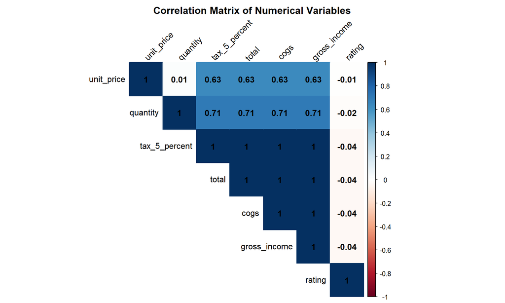

**Key Correlations:**

- Total and cogs: Near-perfect correlation (expected, as cogs is cost of goods sold).
- Quantity and Total: Strong positive correlation.
- Rating shows weak correlations with financial metrics, suggesting rating is independent of transaction value.

# 9 Interactive Data Explorer

|  | invoice_id | branch | city | customer_type | product_line | total | date | rating |
| --- | --- | --- | --- | --- | --- | --- | --- | --- |
| 1 | 750-67-8428 | A | Yangon | Member | Health and beauty | 548.9715 | 2019-01-05 | 9.1 |
| 2 | 226-31-3081 | C | Naypyitaw | Normal | Electronic accessories | 80.22 | 2019-03-08 | 9.6 |
| 3 | 631-41-3108 | A | Yangon | Normal | Home and lifestyle | 340.5255 | 2019-03-03 | 7.4 |
| 4 | 123-19-1176 | A | Yangon | Member | Health and beauty | 489.048 | 2019-01-27 | 8.4 |
| 5 | 373-73-7910 | A | Yangon | Normal | Sports and travel | 634.3785 | 2019-02-08 | 5.3 |
| 6 | 699-14-3026 | C | Naypyitaw | Normal | Electronic accessories | 627.6165 | 2019-03-25 | 4.1 |
| 7 | 355-53-5943 | A | Yangon | Member | Electronic accessories | 433.692 | 2019-02-25 | 5.8 |
| 8 | 315-22-5665 | C | Naypyitaw | Normal | Home and lifestyle | 772.38 | 2019-02-24 | 8 |
| 9 | 665-32-9167 | A | Yangon | Member | Health and beauty | 76.146 | 2019-01-10 | 7.2 |
| 10 | 692-92-5582 | B | Mandalay | Member | Food and beverages | 172.746 | 2019-02-20 | 5.9 |

[output cut: 90 more lines]

# 10 Recommendations & Action

Based on out analysis, here are actionable recommendations:

1. **Member Conversion:** Develop strategy to convert normal customers to members (currently conversion opportunity: 49.9% of base)
2. **Branch Performance** Share best practices from Branch C to lower-performing branches.
3. **Payment Infrastructure:** Consider promoting Ewallet payment method further.

## 10.3 Long-term opportunities

1. **Personalization:** Use customer segmentation for targeted marketing.
2. **Inventory Optimization:** Align stock levels with product performance data.
3. **Pricing Strategy:** Test price optimization for underperforming product lines.

# 11 Appendix: Data Dictionary

Data Dictionary

| Variables | Description |
| --- | --- |
| Invoice ID | Unique invoice ID |
| Branch | Branch identifier (A, B, C) |
| City | City location |
| Customer type | Member or Normal customer |
| Gender | Gender of customer |
| Product line | Product category |
| Unit price | Price per unit |
| Quantity | Quantity purchased |
| Tax .5 | 5% tax on transaction |
| Total | Total amount including tax |
| Date | Date of transaction |
| Day of Week | Day of week |
| Time | Time of transaction |
| Payment | Payment method used |
| COGS | Cost of goods sold |
| Gross Margin Percenage | Gross margin percentage |
| Gross Income | Gross income |
| Rating | Customer rating(1-10) |

Report generated on 2025-12-07 using R 4.3.1